# Quickstart Guide

```python
from hydrodata import Station, ArcGISREST, WFS
import hydrodata.datasets as hds
from hydrodata import plot, utils, services
import matplotlib.pyplot as plt
import geopandas as gpd
import warnings
```

```python
warnings.filterwarnings("ignore")
```

Here are some examples to quickly get you started with basic capabilities of HydroData. The rest of documentation details other funtionalities of HydroData in more details.

## Station

```python
wshed = Station(station_id='01031500')
wshed.hcdn
```

```
True
```

The `wshed.hcdn` property shows that this station is located in a natural environment and is not affected by human activity.

## NHDPlus

The river network including tributaries and main river channel for the watershed can be retrived from NHDPlus database. Additionally, using the retrieved information such as the watershed geometry we can then use the `datasets` module to access other databases. For example, we can find the USGS stations upstream (or downstream) of the main river channel (or tributatires) up to a certain distance, say 150 km. Also, all the USGS stations inside the watershed can be found:

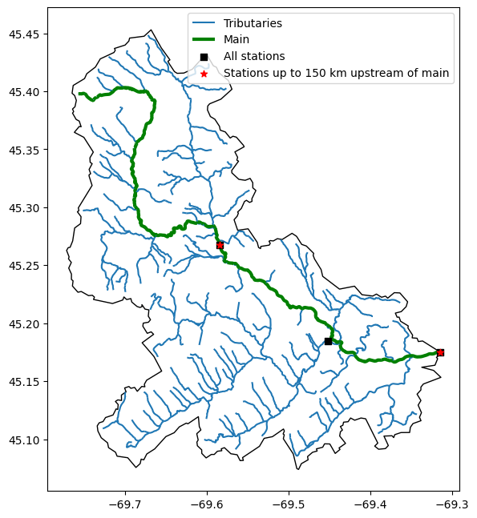

```python
tributaries = hds.NLDI.tributaries(wshed.station_id)
main_channel = hds.NLDI.main(wshed.station_id)
stations = hds.NLDI.stations(wshed.station_id)
stations_upto_150 = hds.NLDI.stations(wshed.station_id, navigation="upstreamMain", distance=150)

ax = wshed.basin.plot(color='white', edgecolor='black', zorder=1, figsize = (8, 8))
tributaries.plot(ax=ax, label='Tributaries', zorder=2)
main_channel.plot(ax=ax, color='green', lw=3, label='Main', zorder=3)
stations.plot(ax=ax, color='black', label='All stations', marker='s', zorder=4)
stations_upto_150.plot(ax=ax, color='red', label='Stations up to 150 km upstream of main', marker='*', zorder=5)
ax.legend(loc='best')
ax.figure.set_dpi(100);
```

## Data for Single Pixel

The climate data and streamflow observations for the location of interest can be retrieved and plotted using `plot` module that plots five hydrologic signatures graphs in one plot.

```python
start, end = "2000-01-01", "2010-01-21"
clm_p = hds.daymet_byloc(wshed.lon, wshed.lat, start=start, end=end)
clm_p['Q (cms)'] = hds.nwis_streamflow(wshed.station_id, start, end)
```

[figure not shown]

```python
plot.signatures({"Q": clm_p['Q (cms)']}, prcp=clm_p["prcp (mm/day)"])
```

## Gridded Datasets

Other than point-based data, gridded data can also be accessed at the desired resolution. Furthermore, the watershed geometry can be used to mask the gridded data.

DEM, slope (in m/m rather than degrees), and aspect can be retrieved for the station's contributing watershed at 1 arc-second (30 m) resolution, as follows:

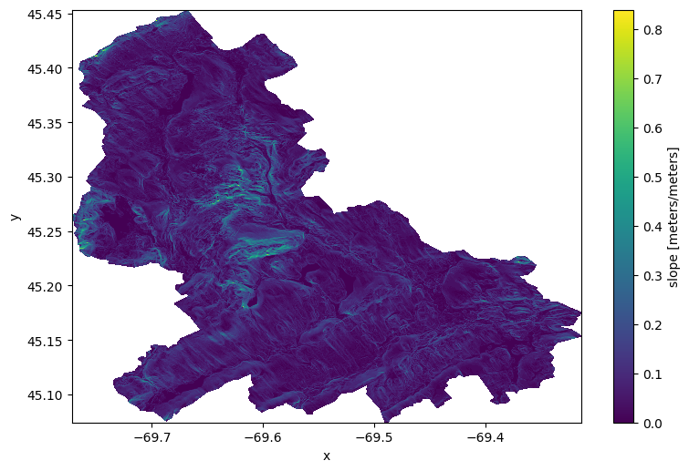

```python
nm = hds.NationalMap(wshed.geometry, resolution=1)
dem, slope, aspect = nm.get_dem(), nm.get_slope(mpm=True), nm.get_aspect()
ax = slope.plot(size=6)
ax.figure.set_dpi(100);
```

```python
variables = ["tmin", "tmax", "prcp"]
clm_g = hds.daymet_bygeom(wshed.geometry, start='2005-01-01', end='2005-01-31', variables=variables, pet=True)
eta_g = hds.ssebopeta_bygeom(wshed.geometry, start='2005-01-01', end='2005-01-31')
```

All the gridded data are returned as [xarray](https://xarray.pydata.org/en/stable/) datasets that has efficient data processing tools. Note that Daymet dataset's projection is [Lambert](https://daymet.ornl.gov/overview).

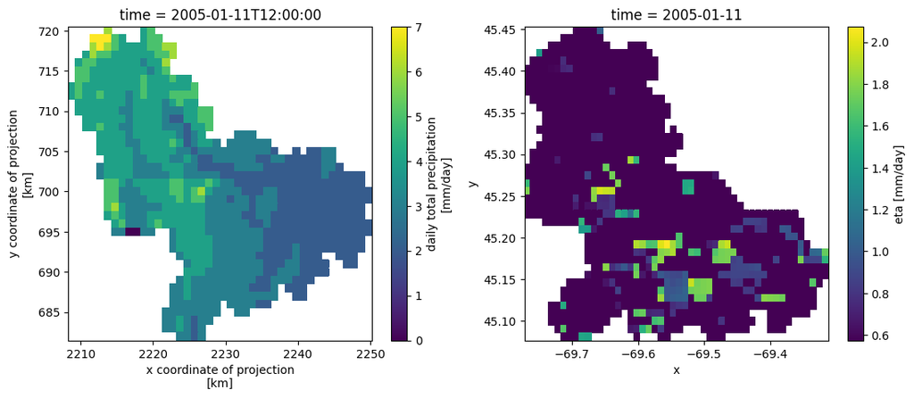

```python
fig, axes = plt.subplots(ncols=2, figsize=(13, 5))
clm_g.prcp.isel(time=10).plot(ax=axes[0])
eta_g.isel(time=10).plot(ax=axes[1])
fig.set_dpi(100);
```